# The influence of compound heat and drought extreme events on ecosystem response variables

Author

Georg Brandt (3750881), Chinthaparthy Deepak Reddy (3793056), Jasmin Krebs (3721364)

Published

July 29, 2024

# Introduction

## Question

As ecosystem response variables we chose Gross Primary Productivity (GPP), Total Ecosystem Respiration (TER) and Evaporative Stress (EvS). Ecosystem responses are influenced by various environmental factors. Gross primary productivity (GPP), the largest flux in the global carbon budget, is mainly influenced by air temperature and precipitation. These environmental factors strongly affect the spatial variation of GPP (Zhu et al. 2016). Higher temperatures and more precipitation typically lead to a higher GPP. However, heat waves slightly decrease GPP and droughts largely decrease GPP (Zscheischler et al. 2014). Higher temperatures and moisture usually lead to a higher total ecosystem respiration (TER). Heat waves increase TER, while droughts decrease TER (Zscheischler et al. 2014). Environmental factors such as a lack of available soil water, decrease in biomass, and extreme temperatures can decrease the potential evaporation. The evaporation stress factor (S) accounts for these effects, with zero indicating maximum evaporative stress (EvS) and one indicating no stress (Miralles et al. 2011).

Global extreme events have been on an increasing trend. The percentage of the global land area experiencing extreme temperatures is rising. Perkins et al. (2020) note an increase in the trends of duration of heat waves, particularly in South America, Africa, the Middle East, and Southwest Asia. Since climate variables like temperature and precipitation influence different ecosystem responses, (extreme) changes in these variables also lead to changing responses. Changes in these responses can affect ecosystem functions and services.

This leads to the question we want to answer in this project:

**How do different ecosystem variables respond to extreme events with different area, duration and severity on a global scale?**

## Data

There is a summary table for all extreme events that have been detected in the DeepExtremes project (https://s3.bgc-jena.mpg.de:9000/deepextremes/v3/MergedEventStats_landonly.csv). We use this summary to obtain the drought indicator PEI (total precipitation - potential evapotranspiration) of each event as well as some more information, like start and end time and the label of each event.

As input data for the ecosystem response variables we use the FLUXCOM and GLEAM data sets from the Earth System Data Cube (https://deepesdl.readthedocs.io/en/latest/datasets/ESDC/).

The PEI mean parameters in the data frame of the summary CSV for all extreme events will be our parameters to describe the severity of a drought event. We will later examine all moving averages of PEI (30, 90 and 180 days) on possible relationships with the computed ecosystem response that will be done in the next steps. We will also examine the relationship between properties like duration and area of the extreme events and the ecosystem responses.

## Hypothesis

We expect GPP and TER to drop as a response to climate extremes and evaporative stress to increase. We expect negative correlations of PEI as well as duration (and area) with GPP, TER and EvS (we expect the evaporative stress to increase - with 0 indicating maximum stress and 1 indicating no stress - meaning a negative change in the EvS shows increasing stress).

# 1. Determining all extreme events that will be used in the analysis with the CSV summary

We first load the summary table of all DeepExtremes events and create a dataframe of it that fits our purposes. We require the duration of each event to be numeric, we remove events that are shorter than five days as we expect them to have no observable influence on the vegetation parameters we are looking at (because of water and energy stocks in the vegetation) and we convert start and end date to actual datetime objects as we will work with dates.

```python
# Load summary table of DeepExtremes events
df_summary = pd.read_csv("https://s3.bgc-jena.mpg.de:9000/deepextremes/v3/MergedEventStats_landonly.csv")

# Create new column 'duration_days' with numeric values
df_summary['duration_days'] = df_summary['duration'].str.extract(r'(\d+)').astype(int)

# Drop events shorter than 5 days
n_entries = len(df_summary)
df_summary = df_summary[df_summary['duration_days'] > 4]

# Output
print(f"Removed {n_entries - len(df_summary)} entries shorter than 5 days.")
print(f"Final dataframe has {len(df_summary)} entries.")

# Convert date columns from strings to actual datetime objects
df_summary['start_time'] = pd.to_datetime(df_summary['start_time'])
df_summary['end_time'] = pd.to_datetime(df_summary['end_time'])

# Set the label as the index  as unique identifier to iterate over
df_summary.set_index('label', inplace=True)

# Sort dataframe by event label
df_summary = df_summary.sort_index()

df_summary
```

```
Removed 20592 entries shorter than 5 days.
Final dataframe has 17052 entries.
```

| label | start_time | end_time | longitude_min | longitude_max | latitude_min | latitude_max | t2mmax_mean | t2mmax_min | t2mmax_max | pei_30_mean | ... | compound | land_share | inth | intd30 | intd90 | intd180 | volume | duration | area | duration_days |
| --- | --- | --- | --- | --- | --- | --- | --- | --- | --- | --- | --- | --- | --- | --- | --- | --- | --- | --- | --- | --- | --- |
| 14 | 1950-01-11 | 1950-01-16 | 114.25 | 114.50 | -27.00 | -26.50 | 44.599605 | 43.539326 | 45.413027 | -7.025987 | ... | 100.0 | 100.0 | -2197.870687 | -2209.813765 | -2210.004473 | -2210.004473 | 22.332210 | 6 days | 3.722035 | 6 |
| 15 | 1950-01-26 | 1950-01-30 | 298.75 | 299.25 | -33.25 | -32.75 | 37.933651 | 36.734158 | 39.611113 | -1.632370 | ... | 100.0 | 100.0 | -3056.710160 | -2910.030618 | -3036.552760 | -3065.436402 | 31.037756 | 5 days | 6.207551 | 5 |
| 19 | 1950-02-05 | 1950-02-09 | 300.50 | 302.75 | -37.75 | -36.25 | 35.519271 | 31.567478 | 37.487799 | -2.345271 | ... | 100.0 | 100.0 | -13213.541106 | -13148.366933 | -13277.100530 | -13279.837853 | 134.192764 | 5 days | 26.838553 | 5 |
| 20 | 1950-02-05 | 1950-02-09 | 299.25 | 300.00 | -37.75 | -37.25 | 35.348742 | 34.404432 | 36.815762 | -3.030102 | ... | 100.0 | 100.0 | -1870.987606 | -1873.963978 | -1882.232297 | -1882.232297 | 19.019110 | 5 days | 3.803822 | 5 |
| 21 | 1950-02-08 | 1950-02-13 | 114.25 | 114.75 | -27.25 | -26.75 | 44.641825 | 43.878544 | 45.667441 | -5.830572 | ... | 100.0 | 100.0 | -1755.231763 | -1746.816866 | -1761.649739 | -1761.683156 | 17.820063 | 6 days | 2.970010 | 6 |
| ... | ... | ... | ... | ... | ... | ... | ... | ... | ... | ... | ... | ... | ... | ... | ... | ... | ... | ... | ... | ... | ... |
| 58355 | 2022-11-25 | 2022-11-30 | 300.00 | 301.50 | -29.75 | -28.00 | 39.908894 | 38.097432 | 41.323206 | -2.456772 | ... | 100.0 | 100.0 | -15985.973679 | -15796.405036 | -15938.433192 | -15897.571823 | 162.000682 | 6 days | 27.000114 | 6 |
| 58356 | 2022-11-25 | 2022-11-29 | 293.75 | 293.75 | -34.50 | -34.25 | 41.932918 | 39.318298 | 43.792140 | -3.039994 | ... | 100.0 | 100.0 | -734.525216 | -721.508821 | -730.321068 | -716.848870 | 7.429454 | 5 days | 1.485891 | 5 |
| 58357 | 2022-11-26 | 2022-11-30 | 294.00 | 294.50 | -16.75 | -16.25 | 39.384733 | 34.545239 | 43.540926 | -0.030447 | ... | 100.0 | 100.0 | -2081.628493 | -2027.181788 | -2005.652492 | -2073.265960 | 21.095119 | 5 days | 4.219024 | 5 |
| 58358 | 2022-12-04 | 2022-12-11 | 292.50 | 301.00 | -34.50 | -21.25 | 42.989625 | 32.274716 | 47.315530 | -3.304211 | ... | 100.0 | 100.0 | -200544.299585 | -197410.490247 | -199372.539714 | -200117.319340 | 2031.911375 | 8 days | 253.988922 | 8 |
| 58365 | 2022-12-20 | 2022-12-24 | 299.25 | 299.50 | -65.75 | -65.75 | 13.414851 | 11.636800 | 15.840227 | -0.495590 | ... | 100.0 | 100.0 | -364.157468 | -363.342593 | -203.533014 | -288.414090 | 3.696470 | 5 days | 0.739294 | 5 |

17052 rows × 32 columns

# 2. Defining core area of all extreme events

As a next step, we create masks for all events in the DeepExtremes database. An event mask includes all pixels that have been part of the respective event at least during one day. The masks are later used to compute the ecosystem response over event-affected area only. This ensures that no other area than the actual event area affect the calculation of the response parameters.

We load the DeepExtremes labelcube that contains all events that were identified in the project. The values of this datacube correspond to the labels of the events from the summary table. Thus, each event is represented as a number of connected pixels that span over the time and space dimensions of the datacube.

```python
# Load labelcube
ds_blobs = xr.open_zarr('https://s3.bgc-jena.mpg.de:9000/deepextremes/v3/mergedlabels.zarr')
```

We define a dictionary that contains a list of all time stamps for each event in df_summary. These will be used to retrieve the time slices for each event that will be merged to the core area in the last step.

```python
# Function to create a list of timestamps from given start and end date
def generate_date_list(start_date, end_date):
  """
  Generates a list of daily timestamps (date objects) from a start date to an end date of an event.

  Args:
      start_date (datetime.date): The starting date (inclusive).
      end_date (datetime.date): The ending date (inclusive).

  Returns:
      list: A list of datetime.date objects representing daily timestamps.
  """
  date_list = []
  current_date = start_date
  while current_date <= end_date:
    date_list.append(current_date)
    current_date += timedelta(days=1)
  return date_list

# Initialize an empty dictionary
dict_label_dates = {}

# Iterate over all events in the dataframe df_summary
for index, row in df_summary.iterrows():
    start_date = row['start_time'] # Set start date of respective event
    end_date = row['end_time'] # Set end date of respective event
    dates_list = generate_date_list(start_date, end_date) # Create list of daily time stamps between start and end date
    dict_label_dates[index] = dates_list # Write this list to the dictionary
```

The next step is the actual creation of one core area mask for each event in df_summary. As this process is very time and memory consuming, the following code won’t be executed in this documentation. In the source code, the results will be written to file directly. Each iteration writes a core area mask as a numpy array using the .npy file format. Each of these files will be named after the corresponding event label which will be helpful later on when using these as masks for the calculation of ecosystem response.

```python
# Loop over each label and its associated event days

for label, event_days in dict_label_dates.items():

    # Initialize core_area_mask as a boolean array of the same shape as a single time slice, filled with False
    time_slice_shape = ds_blobs.sel(Ti=event_days[0])['labels'].shape
    core_area_mask = np.zeros(time_slice_shape, dtype=bool)

    # Loop over each date to update the core_area_mask
    for event_day in event_days:
        time_slice = ds_blobs.sel(Ti=event_day)  # Get one time slice of the event per iteration
        event_mask = ma.masked_where(time_slice['labels'] != label, time_slice['labels'])  # Mask time slice where the label exists

        # Update core_area_mask: True where label occurs at least once
        core_area_mask = np.logical_or(core_area_mask, event_mask == label)

    # Convert the final core_area_mask to a general array
    core_area_mask = np.asarray(core_area_mask)

    # Save the core_area_mask to a file named after the label
    filename = os.path.join(data_directory, f"{label}.npy")
    np.save(filename, core_area_mask)
```

# 3. Compute ecosystem response

After the core area masks for all events are computed, we want to know how the events impact the vegetation over their respective area. To do so, we compute the delta values for Gross Primary Productivity (GPP), Terrestrial Ecosystem Respiration (TER) and Evaporative Stress (EvS). To obtain these delta values, we compute the average of the respective variable over the whole area and over 14 days before the event and the average over the whole area and 14 days after the event. The difference of these two averages is our delta value.

## 3.1 Open and prepare ecosystem response data from Earth System Data Cube

```python
# Load cube
store = new_data_store("s3", root="deep-esdl-public", storage_options=dict(anon=True))
ds_esdc = store.open_data('esdc-8d-0.25deg-1x720x1440-3.0.1.zarr')
```

```python
# Load required datasets
gpp = ds_esdc['gross_primary_productivity']
ter = ds_esdc['terrestrial_ecosystem_respiration']
evs = ds_esdc['evaporative_stress']
```

As there is not enough data available of our ecosystem variables to compare them with the full dataset of extreme events, we create two dataframes that are limited to the time period of the respective available data. The metadata of the datasets is obtained from the [DeepESDL Documentation](https://deepesdl.readthedocs.io/en/latest/datasets/ESDC/#gross_primary_productivity).

```python
# Limit blob data to the same period as FLUXCOM data
df_fluxcom = df_summary[(df_summary['start_time'] >= '2001-01-05') & (df_summary['end_time'] <= '2020-12-30')]

# Limit blob data to the same period as GLEAM data
df_gleam = df_summary[(df_summary['start_time'] >= '1980-01-05') & (df_summary['end_time'] <= '2021-12-31')]
```

## 3.2 Visualizing event #42561 to get an idea of what we are working with

Now all core area masks are created and saved to storage. Here, we will visualize the event #42561 which is the event for the Russian heatwave in 2010.

```python
# Retrieve dates of event # 42561
def generate_timestamps(start_time, end_time):
    timestamps = []
    current_time = start_time
    while current_time <= end_time:
        timestamps.append(current_time)
        current_time += timedelta(days=1)
    return timestamps

dates_list = generate_timestamps(df_summary.loc[42561, 'start_time'], df_fluxcom.loc[42561, 'end_time'])
```

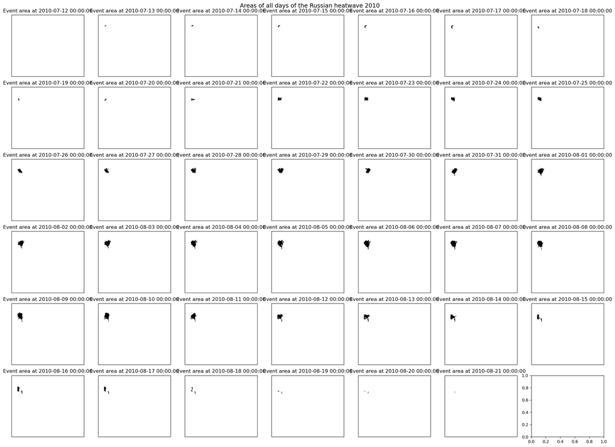

The above plots show the area of all time slices of the Russian heatwave where both drought and temperature are extreme. They were merged to one mask in step 2. The next plot shows the Gross Primary Productivity with the core area mask applied on the first day and on the last day of the event. For this plot, the according mask is loaded and prepared to match the grid and dimensions of the GPP dataset. The core area masks are already precomputed which was done in *01_create_core_area_masks.ipynb*. They will be loaded into memory separately of this notebook when needed.

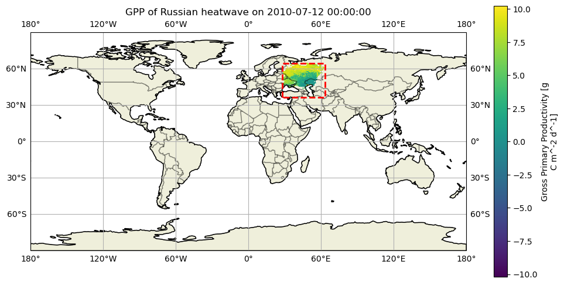

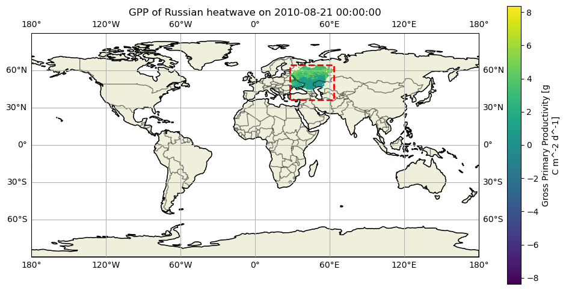

On the first glance, you can observe that the GPP values on the masked data are lower at the end of the event than at the beginning. As a comparison we show the bounding box (red dashed line) of lat_min, lat_max, lon_min and lon_max of the event. It can be seen that this includes a lot of areas that aren’t actually covered by this extreme event. Using the bounding box area to compute the following values would therefore introduce false values and skew the following calculations. For this reason we decided for the computational more intensive core area approach.

## 3.3. Compute ecosystem response parameters

For all events that are left over in the dataframes df_fluxcom and df_gleam, we compute ecosystem response parameters. We will use Gross Primary Productivity (GPP), Terrestrial Ecosystem Respiration (TER) and Evaporative Stress (EvS). For each of these we will compute the average of the 14 days before and of the 14 days after each event over the whole area that was affected by the respective event. From these two means, we compute the difference (delta). These can give us some insights in how vegetation in the respective area responded to the compund drought and heat event. Because this computation is quite time consuming and the code chunks are quite big, we won’t execute it here, but you can have a look at the code in the script *02_compute_ecosystem_response.ipynb*.

# 4. Analysis

## 4.1. Plot world map for GPP, TER, EvS

For a first visual impression, we plot some maps of the spatial and temporal global distribution of the extreme events and their respective ecosystem response variables.

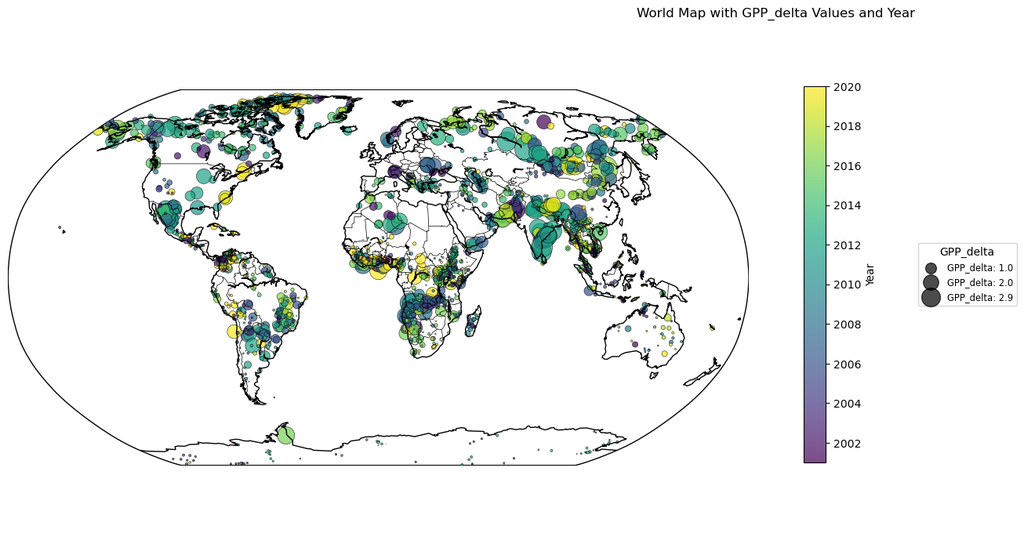

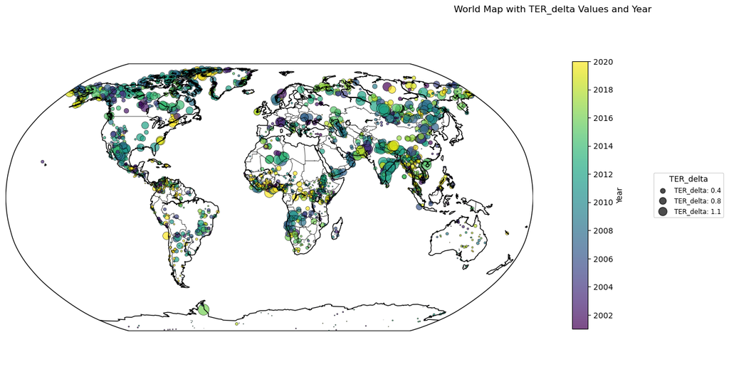

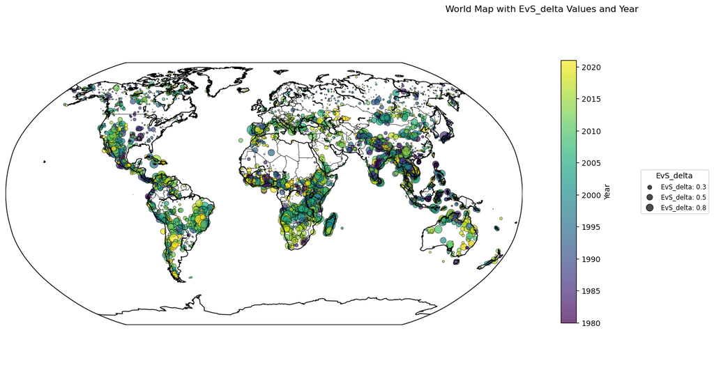

## 4.2. Correlation - globally

Now we take a look at the correlations between the computed ecosystem response variables (delta values for GPP, TER and EvS) and the respective PEI drought indices (with different moving average windows).

```
____Correlations of ecosystem response vs. drought indicators____
        PEI30     PEI90    PEI180
GPP -0.080649 -0.120805 -0.096283
TER -0.002114  0.033219  0.018175
EvS -0.129059 -0.169616 -0.187409
____Mean correlation per ecosystem vairable____
GPP   -0.099246
TER    0.016426
EvS   -0.162028
dtype: object
____Mean correlation per PEI parameter____
PEI30    -0.070607
PEI90    -0.085734
PEI180   -0.088506
dtype: object
Overall mean: 0.09303650031909032
____Mean correlation per PEI parameter (absolute values)____
PEI30     0.070607
PEI90      0.10788
PEI180    0.100622
dtype: object
```

As can be seen, the overall correlations are quite weak. The mean correlation for PEI180 is the strongest for the 3 different PEI values (-0.088506 compared to PEI30 -0.070607 and PEI90 -0.085734). However, when looking at the *absolute* values, PEI90 shows a slightly better correlation (0.10788 compared to PEI30 0.070607 and PEI180 0.100622) because it accounts for the different positive and negative values for GPP, TER and EvS for the different PEIs.

We also look at the correlations between the ecosystem response variables and the properties *duration* and *area* of the extreme events.

```
____Correlations of ecosystem response vs. blob sizes____
     duration      area
GPP -0.011508 -0.071357
TER   0.01078   0.02798
EvS  0.022614  0.048827
____Mean correlation per ecosystem vairable____
GPP   -0.041433
TER     0.01938
EvS     0.03572
dtype: object
____Mean correlation per event size parameter____
duration    0.007295
area        0.001817
dtype: object
Overall mean: 0.03217764996861122
____Mean correlation per event size parameter (absolute values)____
duration    0.014967
area        0.049388
dtype: object
```

As for the PEI, the overall correlations are very weak. The mean correlation for the duration is stronger than for the area (duration 0.007295 vs. area 0.001817). However, when looking at the *absolute* values, the mean correlation for the area is stronger (duration 0.014967 vs. area 0.049388).

## 4.3. Continent-wise correlations

### 4.3.1 Assign events to a continent

```python
# Load the world shapefile from GeoPandas
world = gpd.read_file(gpd.datasets.get_path('naturalearth_lowres'))

# For Fluxcom
# Adjust longitude values to handle the -180 to 180 range
df_fluxcom['longitude_min'] = df_fluxcom['longitude_min'].apply(lambda x: x if x <= 180 else x - 360)
df_fluxcom['longitude_max'] = df_fluxcom['longitude_max'].apply(lambda x: x if x <= 180 else x - 360)

def create_event_polygon(row):
    """Create a polygon from the event's latitude and longitude."""
    return Polygon([
        (row['longitude_min'], row['latitude_min']),
        (row['longitude_max'], row['latitude_min']),
        (row['longitude_max'], row['latitude_max']),
        (row['longitude_min'], row['latitude_max']),
    ])

def assign_continent(row):
    """Assign the most frequently intersecting continent to the event based on its polygon."""
    event_polygon = create_event_polygon(row)
    intersecting_continents = []

    for _, continent in world.iterrows():
        if event_polygon.intersects(continent.geometry):
            intersecting_continents.append(continent['continent'])  # Collect all intersecting continents

    if intersecting_continents:
        # Determine the most frequent intersecting continent
        return Counter(intersecting_continents).most_common(1)[0][0]
    else:
        return None  # Return None if no continents intersect

# Apply the function to assign the most frequent continent
df_fluxcom['largest_continent'] = df_fluxcom.apply(assign_continent, axis=1)

# For gleam
# Adjust longitude values to handle the -180 to 180 range
df_gleam['longitude_min'] = df_gleam['longitude_min'].apply(lambda x: x if x <= 180 else x - 360)
df_gleam['longitude_max'] = df_gleam['longitude_max'].apply(lambda x: x if x <= 180 else x - 360)

def create_event_polygon(row):
    """Create a polygon from the event's latitude and longitude."""
    return Polygon([
        (row['longitude_min'], row['latitude_min']),
        (row['longitude_max'], row['latitude_min']),
        (row['longitude_max'], row['latitude_max']),
        (row['longitude_min'], row['latitude_max']),
    ])

def assign_continent(row):
    """Assign the most frequently intersecting continent to the event based on its polygon."""
    event_polygon = create_event_polygon(row)
    intersecting_continents = []

    for _, continent in world.iterrows():
        if event_polygon.intersects(continent.geometry):
            intersecting_continents.append(continent['continent'])  # Collect all intersecting continents

    if intersecting_continents:
        # Determine the most frequent intersecting continent
        return Counter(intersecting_continents).most_common(1)[0][0]
    else:
        return None  # Return None if no continents intersect

# Apply the function to assign the most frequent continent
df_gleam['largest_continent'] = df_gleam.apply(assign_continent, axis=1)
```

### 4.3.2 Continent-wise correlations with PEIs

```
____Correlation results for GPP_PEIs:____
  Africa:
    pei_30: 0.08620745187874006
    pei_90: 0.11074954557435135
    pei_180: 0.1452228995552068
  Antarctica:
    pei_30: -0.2981370581549792
    pei_90: -0.07296814979877767
    pei_180: -0.04793673766372653
  Asia:
    pei_30: 0.033298275425558105
    pei_90: -0.051509383312980356
    pei_180: -0.03224770420221282
  Europe:
    pei_30: 0.08374276021930145
    pei_90: 0.06617231542806933
    pei_180: 0.03418258646128389
  North America:
    pei_30: -0.1112264584645062
    pei_90: -0.10516274938313803
    pei_180: -0.11465067051199442
  Oceania:
    pei_30: -0.45220740499718637
    pei_90: -0.5776238332659069
    pei_180: -0.591838949220662
  South America:
    pei_30: -0.06958365813335372
    pei_90: -0.18315521053383896
    pei_180: -0.21040764056641717
____Correlation results for TER_PEIs:____
  Africa:
    pei_30: 0.03449767493805898
    pei_90: 0.14015125401524728
    pei_180: 0.26239022501227527
  Antarctica:
    pei_30: -0.27254640338262714
    pei_90: -0.29459870024330154
    pei_180: -0.21113420850361408
  Asia:
    pei_30: 0.09179722276735036
```

[output cut: 32 more lines]

```
    pei_30: -0.018054246293101022
    pei_90: -0.06790113879134545
    pei_180: -0.09837482591863378
  North America:
    pei_30: -0.1678643236020429
    pei_90: -0.20502940722616228
    pei_180: -0.21267399859477074
  Oceania:
    pei_30: -0.23386186395246278
    pei_90: -0.2720351266443546
    pei_180: -0.2723178910001364
  South America:
    pei_30: -0.1774526659230655
    pei_90: -0.2753518773480404
    pei_180: -0.3145613083404826
```

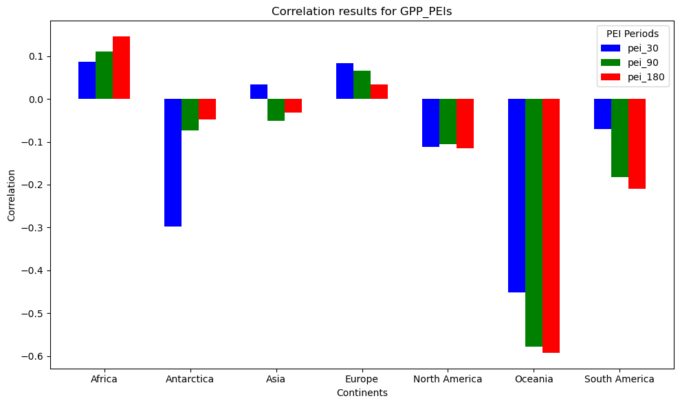

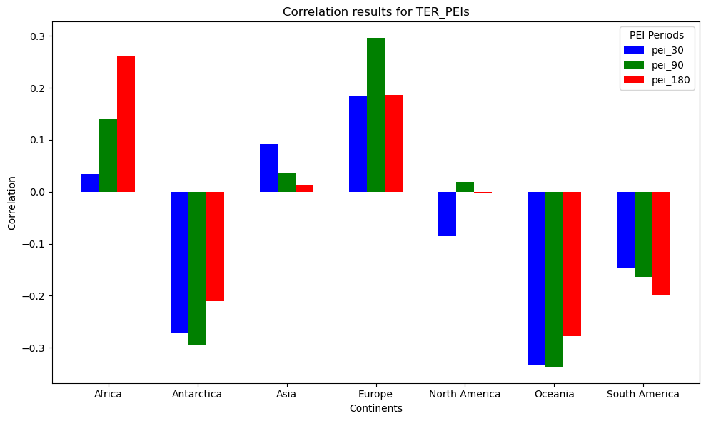

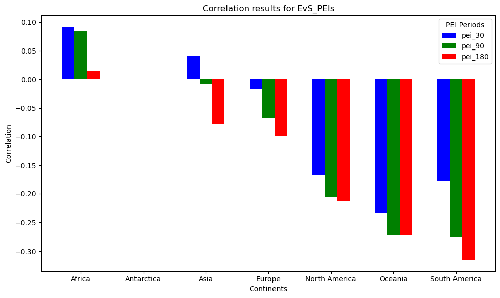

The correlations vary significantly across continents and PEI types. Africa generally shows positive correlations for GPP, TER and EvS, while other continents, particularly Oceania and South America, exhibit strong negative correlations. EvS correlations tend to be negative across most regions except for Africa and PEI 30 for Asia.

Since PEI 180 seems to have the strongest correlations across the different continents and PEI types, we will now visualize the correlations between GPP (TER, EvS) and PEI 180 in some scatter plots.

### Plot some results

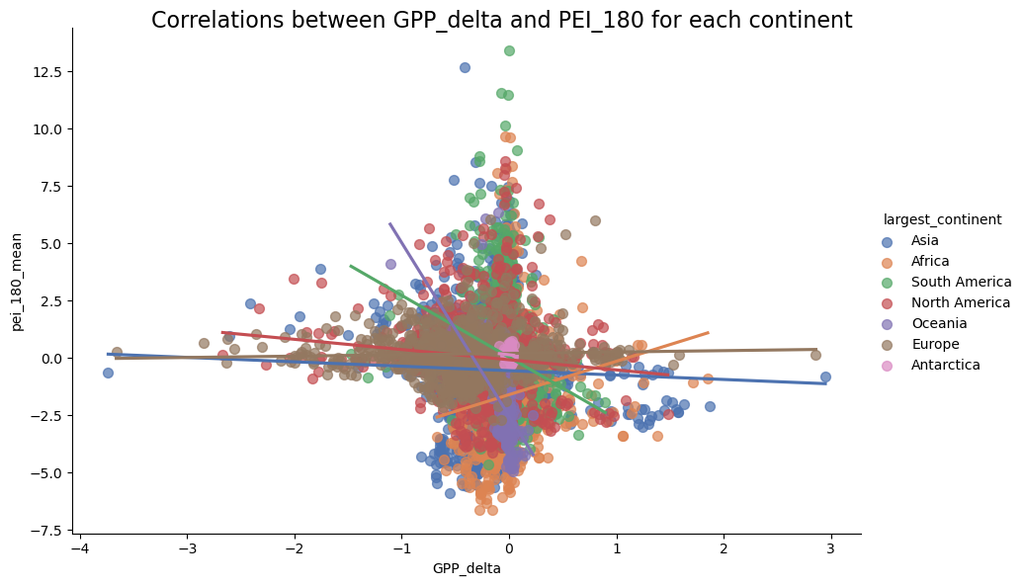

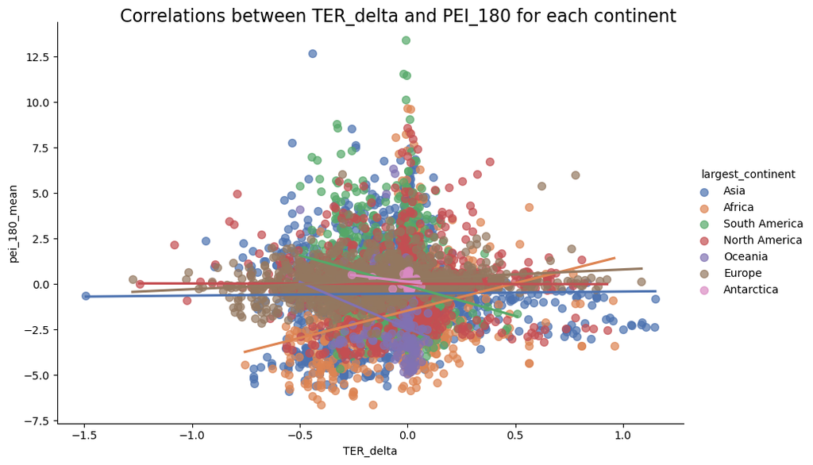

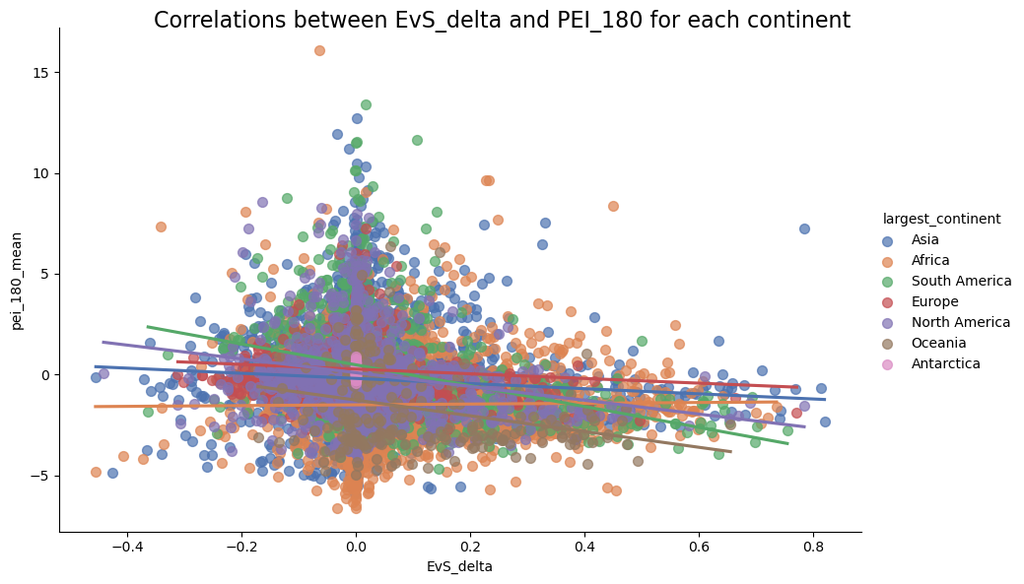

### 4.3.2 Continent-wise correlations with event size parameters

```
___Correlation results for GPP_properties:___
  Africa:
    duration_days: 0.29375022373287174
    area: 0.36169411986640737
  Antarctica:
    duration_days: 0.1838705373312725
    area: -0.11799552768435097
  Asia:
    duration_days: -0.11966385714621566
    area: -0.2637959262300692
  Europe:
    duration_days: -0.20519020441013858
    area: -0.17037852230634762
  North America:
    duration_days: -0.016914053802964926
    area: -0.11504206861876576
  Oceania:
    duration_days: -0.3043371812254034
    area: 0.023637715782977374
  South America:
    duration_days: 0.03718193052349404
    area: 0.22402916019019897
___Correlation results for TER_properties:___
  Africa:
    duration_days: 0.258403402204057
    area: 0.3033405856283164
  Antarctica:
    duration_days: -0.01268452963273256
    area: -0.04988891811008264
  Asia:
    duration_days: -0.09377044061334296
    area: -0.11816599598240737
  Europe:
    duration_days: -0.12093677096887442
    area: -0.009233081577201015
  North America:
    duration_days: 0.01539426769523272
    area: -0.030328456312324337
  Oceania:
    duration_days: -0.2397981001437491
```

[output cut: 11 more lines]

```
  Asia:
    duration_days: -0.019548463870003863
    area: 0.0008200088402327383
  Europe:
    duration_days: -0.028844404030216625
    area: 0.010577307822596953
  North America:
    duration_days: -0.01875225562172703
    area: 0.019461475689649878
  Oceania:
    duration_days: 0.11438425165705196
    area: 0.08045647685134852
  South America:
    duration_days: -0.030958210283010587
    area: 0.14526905552485717
```

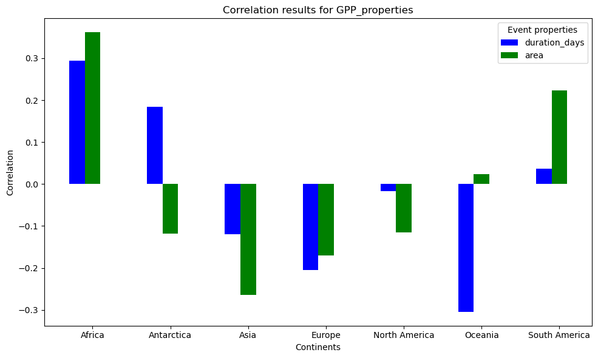

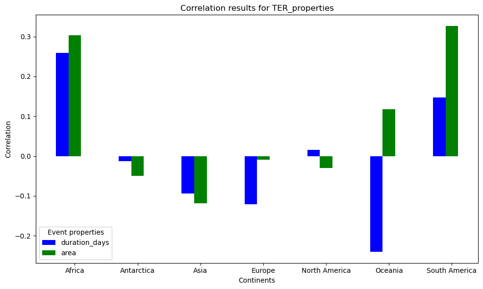

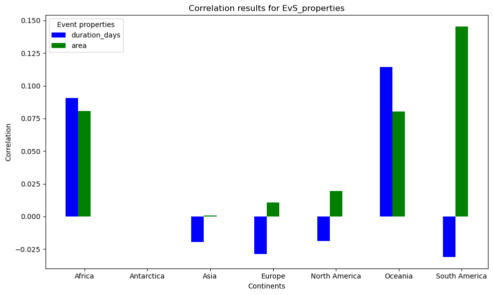

# 5. Conclusions

The global correlations we found were quite weak with the PEI showing a slightly higher correlation than duration and area of the extreme events. Significant variability in correlations was observed across different continents. Especially Africa often showed a positive response, when most other continents displayed negative responses. This indicates that different ecosystems respond very differently to (changing) environmental conditions, and thus, results should not be generalized on a global scale. African vegetation appears to be better adapted to higher temperatures and drier conditions, potentially leading to increased productivity under these conditions. However, this trend probably persists only up to a certain threshold, beyond which vegetation responses would become negative. In contrast, other ecosystems may reach this threshold more rapidly, thereby exhibiting negative responses at earlier stages.

Further research could try to identify time lags in the ecosystem response. It is possible e. g. to compute a full time series from 14 days before to after the event instead of only using the mean values. This could improve understanding of how ecosystems actually respond during the event surge and after it in the rehabilitation phase. This could be done for all events, for some chosen big events or just certain regions.

# References

Miralles, D. Gonzalez, et al. “Global land-surface evaporation estimated from satellite-based observations.” Hydrology and Earth System Sciences 15.2 (2011): 453-469. doi.org/10.5194/hess-15-453-2011

Zhu, Xian-Jin, et al. “Approaches of climate factors affecting the spatial variation of annual gross primary productivity among terrestrial ecosystems in China.” Ecological Indicators 62 (2016): 174-181. doi.org/10.1016/j.ecolind.2015.11.028

Zscheischler, Jakob, et al. “Impact of large‐scale climate extremes on biospheric carbon fluxes: An intercomparison based on MsTMIP data.” Global Biogeochemical Cycles 28.6 (2014): 585-600. doi.org/10.1002/2014GB004826

Perkins-Kirkpatrick, S. E., and S. C. Lewis. “Increasing trends in regional heatwaves.” Nature communications 11.1 (2020): 3357. doi.org/10.1038/s41467-020-16970-7